# Data Analysis to identify the potential customers who have a higher probability of purchasing the loan.

# Print Accuracy and Confusion Matrix

```python
def GaussianNBModelPerformanceAnalysis(X, y, test_size = 0.3, seed = 7):
    X_train, X_test, y_train, y_test = train_test_split(X, y, test_size=test_size, random_state=seed)
    model = GaussianNB()
    model.fit(X_train, y_train)
    ### Unoptimized probability threshold based performance numbers
    # Train accuracy numbers
    trainPreds = np.where(model.predict_proba(X_train)[:,1] > 0.5, 1, 0)
    trainAccuracy = accuracy_score(y_train, trainPreds)
    trainRecall = recall_score(y_train, trainPreds)
    trainPrecision = precision_score(y_train, trainPreds)
    trainF1score = f1_score(y_train, trainPreds)
    trainResults=[X_train.shape[0], 0.5, trainAccuracy, trainRecall, trainPrecision, trainF1score]
    # Test accuracy numbers
    testPreds = np.where(model.predict_proba(X_test)[:,1] > 0.5, 1, 0)
    testAccuracy = accuracy_score(y_test, testPreds)
    testRecall = recall_score(y_test, testPreds)
    testPrecision = precision_score(y_test, testPreds)
    testF1score = f1_score(y_test, testPreds)
    testResults=[X_test.shape[0], 0.5, testAccuracy, testRecall, testPrecision, testF1score]

    #### Optimize probability threshold and calculate performance numbers
    y_predictProb = model.predict_proba(X_train)
    fpr, tpr, thresholds = roc_curve(y_train, y_predictProb[::,1])
    optimalF1 = 0
    optimalTh = 0
    for th in thresholds:
        preds = np.where(model.predict_proba(X_train)[:,1] > th, 1, 0)
        f1Score = f1_score(y_train, preds)
        if(optimalF1 < f1Score):
            optimalF1 = f1Score
            optimalTh = th

    # Optimal probability threshold based train accuracy numbers
    trainPreds = np.where(model.predict_proba(X_train)[:,1] > optimalTh, 1, 0)
    trainAccuracy = accuracy_score(y_train, trainPreds)
    trainRecall = recall_score(y_train, trainPreds)
    trainPrecision = precision_score(y_train, trainPreds)
    trainF1score = f1_score(y_train, trainPreds)
    optimalTrainResults=[X_train.shape[0], optimalTh, trainAccuracy, trainRecall, trainPrecision, trainF1score]
    # Optimal probability threshold based test accuracy numbers
    testPreds = np.where(model.predict_proba(X_test)[:,1] > optimalTh, 1, 0)
    testAccuracy = accuracy_score(y_test, testPreds)
    testRecall = recall_score(y_test, testPreds)
    testPrecision = precision_score(y_test, testPreds)
    testF1score = f1_score(y_test, testPreds)
    optimalTestResults=[X_test.shape[0], optimalTh, testAccuracy, testRecall, testPrecision, testF1score]
    # Concatenate Train and Test results to resultsDf
    resultsDf = pd.DataFrame( index=["dataSize", "optimalTh", "accuracy", "recall", "precision", "f1_score"])
    resultsDf['unOptimalTrainResults'] = trainResults
    resultsDf['unOptimalTestResults'] = testResults
    resultsDf['optimalTrainResults'] = optimalTrainResults
    resultsDf['optimalTestResults'] = optimalTestResults

    return resultsDf.round(2)
```

```python
GaussianNBModelPerformanceAnalysis(X, y, test_size = 0.3, seed = 7)
```

|  | unOptimalTrainResults | unOptimalTestResults | optimalTrainResults | optimalTestResults |
| --- | --- | --- | --- | --- |
| dataSize | 3500.00 | 1500.00 | 3500.00 | 1500.00 |
| optimalTh | 0.50 | 0.50 | 0.06 | 0.06 |
| accuracy | 0.88 | 0.88 | 0.87 | 0.86 |
| recall | 0.56 | 0.59 | 0.81 | 0.85 |
| precision | 0.42 | 0.40 | 0.41 | 0.39 |
| f1_score | 0.48 | 0.48 | 0.54 | 0.54 |

```python
Cm = metrics.confusion_matrix(predicted, y_test)
print("Confusion Matrix : \n",Cm)
```

```
Confusion Matrix :
 [[1237   56]
 [ 125   82]]
```

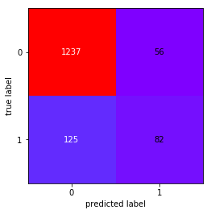

```python
import matplotlib.pyplot as plot
from mpl_toolkits.mplot3d import Axes3D
import matplotlib.cm as cm
fig, ax = plot_confusion_matrix(conf_mat=Cm,cmap = "rainbow")
plot.show()
```

# Analyzing the confusion matrix¶

True Positives (TP): we correctly predicted that they will purchase loan 82

True Negatives (TN): we correctly predicted that they don't purchase loan 1237

False Positives (FP): we incorrectly predicted that they will purchase loan 125

False Negatives (FN): we incorrectly predicted that they don't purchase loan 56

# Give your reasoning on which is the best model in this case and why it performs better? (5 points)

```python
Accuracy_After_Scaling = {'Logistic Regression': logmodel_score, 'K-Nearest Neighbors': knn_testscore, 'Naive Bayes': nbmodel_testscore}
```

```python
print('Overall Model Accuracy After scaling:')
print (Accuracy_After_Scaling)
```

```
Overall Model Accuracy After scaling:
{'Logistic Regression': 0.9546666666666667, 'K-Nearest Neighbors': 0.9666666666666667, 'Naive Bayes': 0.8793333333333333}
```

```python
print("Logistic Regression Confusion Matrix :\n ",lr_cm)
print("\n")
print("k-NN Confusion Matrix : \n",cm)
print("\n")
print("Naive Bayes Confusion Matrix :\n ",Cm)
print("\n")
```

```
Logistic Regression Confusion Matrix :
  [[1351   57]
 [  11   81]]


k-NN Confusion Matrix :
 [[1353    9]
 [  41   97]]


Naive Bayes Confusion Matrix :
  [[1237   56]
 [ 125   82]]
```

# From the above, we can clearly see that k-Nearest neighbors algorithm with scaled data gives us the best accuracy of 96.7%, as well as the least Type 1 (False Positive) and Type 2 (False Negative) errors.

Hence, In the current set of algorithms applied on the available data, K-NN seems to be the best choice to predict the customers who will accept the personal loan.